# Tipología de datos - PRAC2

Francisco Javier Gómez Gálvez

19 de mayo de 2019

# Descripción del Dataset

Se utilizará un conjunto de datos de Kaggle: “Titanic: Machine Learning from Disaster”. Los atributos son:

- PassengerId: identificador único de pasajero
- Survived: Si o no
- Pclass: clase en la que viajaba
- Name: nombre
- Sex: genero
- Age: edad
- SibSp: number of siblings or spouses aboard
- Parch: number of parents or children aboard
- Ticket: ticker number
- Fare: precio del billete
- Cabin: numero de cabina
- Embarked: lugar de embarcacion (C = Cherbourg, Q = Queenstown, S = Southampton)

Asimismo, disponemos de 2 ficheros:

- Conjunto de training: incluye todos los atributos
- Conjunto de test: incluye todos los atributos menos “Survived”

El objetivo es llegar a la creación de un conjunto de reglas que permitan estimar, en base a los atributos de los que disponemos, si un individuo sobreviviría o no.

# Integración y selección de los datos a analizar

Procedemos a la carga de datos de los distintos ficheros.

```r
df_train <- read.csv(".\\Titanic\\train.csv")
df_test <- read.csv(".\\Titanic\\test.csv")
```

Una vez hemos cargado el fichero en un dataframe, podemos obtener una primera descripción de los datos, incluyendo número de registros agregados, nombres de variables, etc. Concretamente, podemos aplicar funciones mas especificas para conocer, respectivamente, el numero de registros total, el numero de variables y los nombres de las mismas:

```r
nrow(df_train)
```

```
## [1] 891
```

```r
ncol(df_train)
```

```
## [1] 12
```

```r
colnames(df_train)
```

```
##  [1] "PassengerId" "Survived"    "Pclass"      "Name"        "Sex"
##  [6] "Age"         "SibSp"       "Parch"       "Ticket"      "Fare"
## [11] "Cabin"       "Embarked"
```

Pasamos a enumerar las columnas con valores vacios o perdidos.

```r
colSums(df_train=="")
```

```
## PassengerId    Survived      Pclass        Name         Sex         Age
##           0           0           0           0           0          NA
##       SibSp       Parch      Ticket        Fare       Cabin    Embarked
##           0           0           0           0         687           2
```

Antes de realizar la limpieza de los datos, intentaremos ver si podemos consolidar atributos y reducir la dimensionalidad del dataset.

Se propone:

- Eliminar los atributos SibSp y Parch en favor de un único atributo “Z_Familia” que indique si la persona viajaba sola o con familiares.
- Eliminar el atributo del Nombre, ya que disponemos del identificador único (PassengerID)
- Eliminar los atributos de Ticket y Cabina, ya que debido a los distintos valores que presentan contribuirían a un posible overfitting del modelo que queramos diseñar.

```r
require(dplyr)
df_train$Z_Familia <- ifelse(df_train$SibSp > 0 | df_train$Parch>0,"Si","No")
df_test$Z_Familia <- ifelse(df_test$SibSp > 0 | df_test$Parch>0,"Si","No")
df_util <- select(df_train,c("PassengerId","Age","Sex","Pclass","Survived","Fare","Embarked","Z_Familia"))
```

# Limpieza de los datos

## Valores perdidos y vacios

Nos centramos en primer lugar en los valores perdidos. Enumeramos:

```r
summary(df_util)
```

```
##   PassengerId         Age            Sex          Pclass
##  Min.   :  1.0   Min.   : 0.42   female:314   Min.   :1.000
##  1st Qu.:223.5   1st Qu.:20.12   male  :577   1st Qu.:2.000
##  Median :446.0   Median :28.00                Median :3.000
##  Mean   :446.0   Mean   :29.70                Mean   :2.309
##  3rd Qu.:668.5   3rd Qu.:38.00                3rd Qu.:3.000
##  Max.   :891.0   Max.   :80.00                Max.   :3.000
##                  NA's   :177
##     Survived           Fare        Embarked  Z_Familia
##  Min.   :0.0000   Min.   :  0.00    :  2    Length:891
##  1st Qu.:0.0000   1st Qu.:  7.91   C:168    Class :character
##  Median :0.0000   Median : 14.45   Q: 77    Mode  :character
##  Mean   :0.3838   Mean   : 32.20   S:644
##  3rd Qu.:1.0000   3rd Qu.: 31.00
##  Max.   :1.0000   Max.   :512.33
##
```

```r
sapply(df_util, function(x) sum(is.na(x)))
```

```
## PassengerId         Age         Sex      Pclass    Survived        Fare
##           0         177           0           0           0           0
##    Embarked   Z_Familia
##           0           0
```

```r
df_util$Age[is.na(df_util$Age)] <- median(df_util$Age, na.rm=TRUE)
df_util$Z_Adulto <- ifelse(df_util$Age < 18, "Menor", "Adulto")
df_test$Z_Adulto <- ifelse(df_test$Age < 18, "Menor", "Adulto")
colSums(df_util=="")
```

```
## PassengerId         Age         Sex      Pclass    Survived        Fare
##           0           0           0           0           0           0
##    Embarked   Z_Familia    Z_Adulto
##           2           0           0
```

Por último, disponemos de valores vacios relativos a la ciudad de origen. Decidimos eliminarlos ya que tiene un impacto mínimo sobre el dataset (2 registros de 1309 es menos del 0,2%)

```r
df_util <- subset(df_util,Embarked!="")
colSums(df_util=="")
```

```
## PassengerId         Age         Sex      Pclass    Survived        Fare
##           0           0           0           0           0           0
##    Embarked   Z_Familia    Z_Adulto
##           0           0           0
```

## Valores extremos

Hacemos uso de boxplot para representar variables cuantitativas

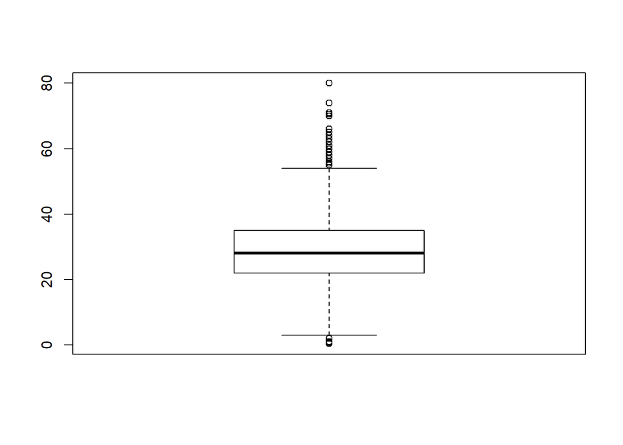

```r
boxplot(df_util$Age)
```

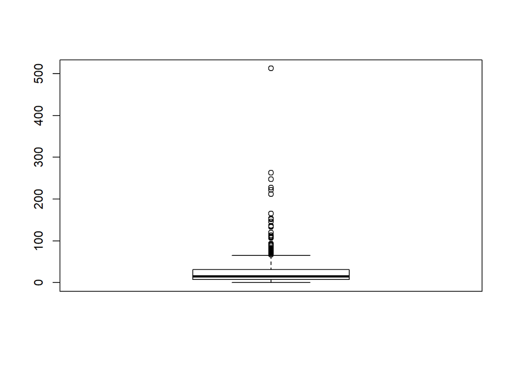

```r
boxplot(df_util$Fare)
```

A la vista de los boxplots, y para evitar que los outliers distorsionen el conjunto de datos, establecemos el siguiente criterio:

- La edad podrá ser cómo máximo 65 años
- La tarifa podrá ser como máximo de 100 dolares

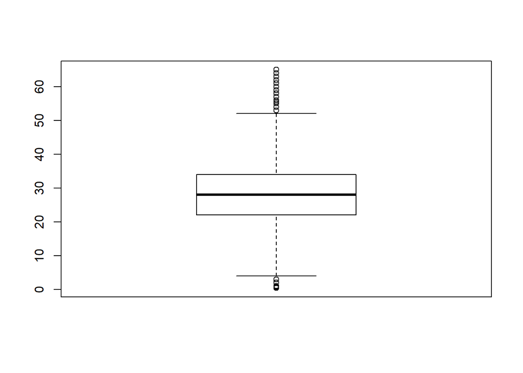

```r
df_util <- subset(df_util, Age <=65 & Fare <= 100)
boxplot(df_util$Age)
```

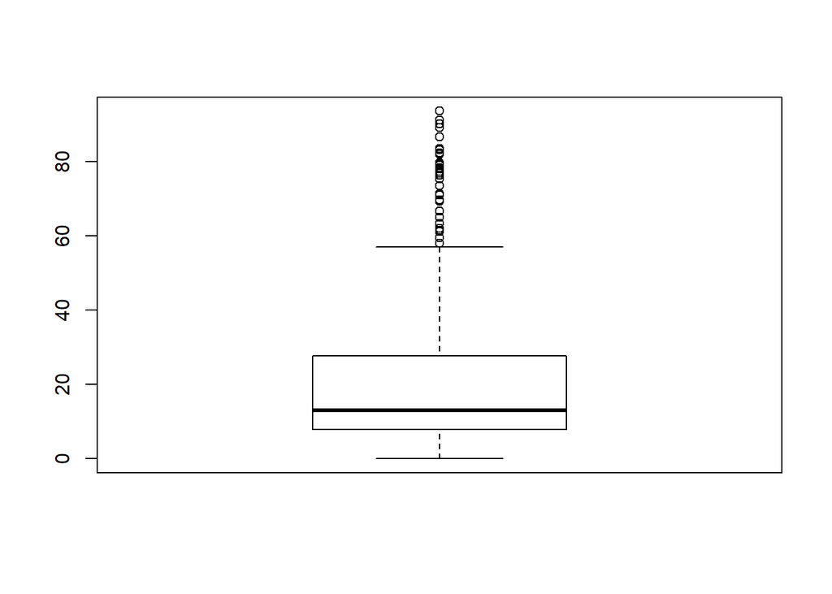

```r
boxplot(df_util$Fare)
```

# Análisis de los datos

## Análisis general

En primer lugar, buscamos ver de modo intuitivo la relación que pueda haber entre la supervivencia y los atributos de los que disponemos.

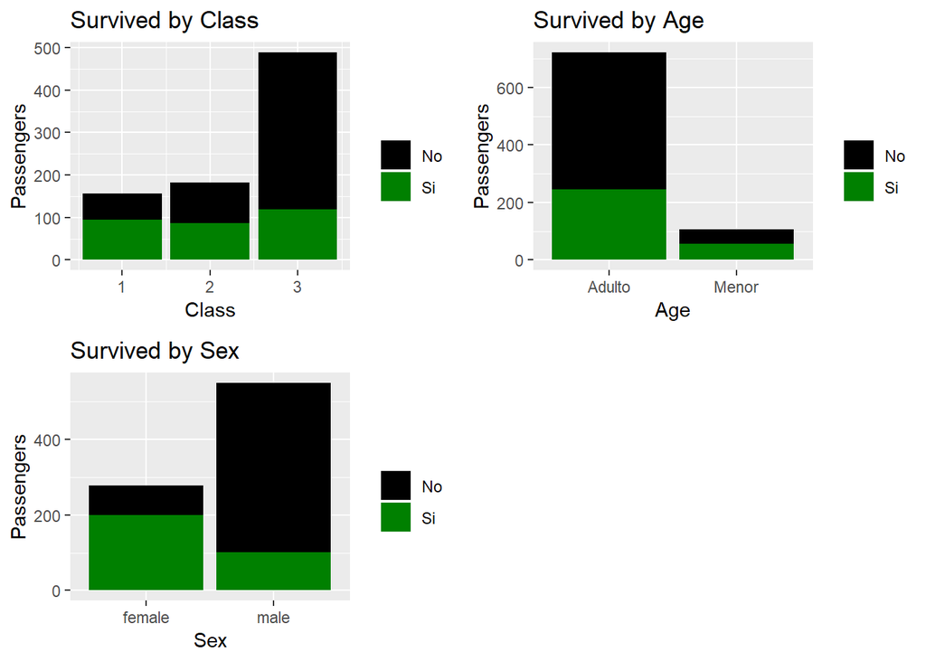

```r
require(ggplot2)
require(grid)
require(gridExtra)

df_util$Survived <- factor(df_util$Survived)
levels(df_util$Survived)=c("No","Si")


grid.newpage()
plotbyClass<-ggplot(df_util,aes(Pclass,fill=Survived))+geom_bar() +labs(x="Class", y="Passengers")+ guides(fill=guide_legend(title=""))+ scale_fill_manual(values=c("black","#008000"))+ggtitle("Survived by Class")
plotbyAge<-ggplot(df_util,aes(Z_Adulto,fill=Survived))+geom_bar() +labs(x="Age", y="Passengers")+ guides(fill=guide_legend(title=""))+ scale_fill_manual(values=c("black","#008000"))+ggtitle("Survived by Age")
plotbySex<-ggplot(df_util,aes(Sex,fill=Survived))+geom_bar() +labs(x="Sex", y="Passengers")+ guides(fill=guide_legend(title=""))+ scale_fill_manual(values=c("black","#008000"))+ggtitle("Survived by Sex")
grid.arrange(plotbyClass,plotbyAge,plotbySex,ncol=2)
```

Podemos ver a partir de las gráficas expuestas que:

- Parece haber correlación entre la clase y la proporcion de personas que se salvan
- Parece haber correlación entre el sexo y la proporcion de personas que se salvan
- Parece haber correlación entre la edad y la proporción de personas que se salvan

Complementamos con tablas de contingencia para poder visualizar las proporciones exactas que hay en cada grupo

```r
t_SST <- table(df_util$Sex, df_util$Survived)
prop.table(t_SST, margin = 1)
```

```
##
##                 No        Si
##   female 0.2841727 0.7158273
##   male   0.8163636 0.1836364
```

```r
t_SCT <- table(df_util$Pclass, df_util$Survived)
prop.table(t_SCT, margin = 1)
```

```
##
##            No        Si
##   1 0.4012739 0.5987261
##   2 0.5219780 0.4780220
##   3 0.7566462 0.2433538
```

```r
t_SAT <- table(df_util$Z_Adulto, df_util$Survived)
prop.table(t_SAT, margin = 1)
```

```
##
##                 No        Si
##   Adulto 0.6606648 0.3393352
##   Menor  0.4811321 0.5188679
```

## Análisis de la varianza

Realizaremos distintos tests para hacernos una idea de la distribución que sigue el conjunto

### Asunción de normalidad y homogeneidad de la varianza

Haremos uso del test de Shapiro, el cual plantea un contraste de hipotesis para discernir si la distribución a analizar sigue una distribución normal o no. La *hipotesis nula* es que nos encontramos ante una distribución normal, la *hipotesis alternativa* es que la distribución no se asemeja a una normal.

Para esta prueba usaremos un nivel de significancia ($\alpha$) de 0.01.

```r
shapiro.test(df_util$Age)
```

```
##
##  Shapiro-Wilk normality test
##
## data:  df_util$Age
## W = 0.95683, p-value = 6.978e-15
```

```r
shapiro.test(df_util$Fare)
```

```
##
##  Shapiro-Wilk normality test
##
## data:  df_util$Fare
## W = 0.76028, p-value < 2.2e-16
```

Tanto en el caso de la edad como el precio del billete, obtenemos un p-valor mucho menor que el nivel de significancia, por lo que rechazamos la hipotesis nula en favor de la hipotesis alternativa: no se sigue una distribución normal, por lo que se deberán usar tests no paramétricos en el futuro.

```r
fligner.test(Age ~ Survived, data=df_util)
```

```
##
##  Fligner-Killeen test of homogeneity of variances
##
## data:  Age by Survived
## Fligner-Killeen:med chi-squared = 6.8897, df = 1, p-value =
## 0.00867
```

```r
fligner.test(Fare ~ Survived, data=df_util)
```

```
##
##  Fligner-Killeen test of homogeneity of variances
##
## data:  Fare by Survived
## Fligner-Killeen:med chi-squared = 66.148, df = 1, p-value =
## 4.183e-16
```

Vemos que no disponemos de suficiente evidencia como para no rechazar la hipotesis nula, por lo que asumismo que nos encontramos ante un conjunto con varianza heterogenea.

### Comparación de grupos de datos

Podemos pasar a hacer uso del test de Wilcox para estudiar si hay diferencias significativas en la varianza en función de la supervivencia para los atributos de los que disponemos (hipotesis nula)

```r
wilcox.test(Age ~ Survived, data = df_util)
```

```
##
##  Wilcoxon rank sum test with continuity correction
##
## data:  Age by Survived
## W = 83940, p-value = 0.1491
## alternative hypothesis: true location shift is not equal to 0
```

```r
wilcox.test(Fare ~ Survived, data = df_util)
```

```
##
##  Wilcoxon rank sum test with continuity correction
##
## data:  Fare by Survived
## W = 52286, p-value = 4.012e-16
## alternative hypothesis: true location shift is not equal to 0
```

Podemos tambien aplicar el test de Kruskal, que es similar al test de Wilcox pero admite más de dos grupos. Esperariamos que nos arrojase resultados similares.

```r
kruskal.test(Age ~ Survived, data = df_util)
```

```
##
##  Kruskal-Wallis rank sum test
##
## data:  Age by Survived
## Kruskal-Wallis chi-squared = 2.0814, df = 1, p-value = 0.1491
```

```r
kruskal.test(Fare ~ Survived, data = df_util)
```

```
##
##  Kruskal-Wallis rank sum test
##
## data:  Fare by Survived
## Kruskal-Wallis chi-squared = 66.233, df = 1, p-value = 4.007e-16
```

Tal y como esperabamos, los resultados coinciden con los proporcionados por el test de Wilcox.

Para afinar más, podemos realizar un test $\chi^2$ para encontrar diferencias significativas entre grupos de variables categóricas. En este caso, la hipotesis nula es que hay independencia entre los atributos, y la hipotesis alternativa es que existe una dependencia entre los atributos.

```r
chisq.test(table(df_util$Z_Adulto,df_util$Survived))
```

```
##
##  Pearson's Chi-squared test with Yates' continuity correction
##
## data:  table(df_util$Z_Adulto, df_util$Survived)
## X-squared = 12.129, df = 1, p-value = 0.0004964
```

```r
chisq.test(table(df_util$Z_Familia,df_util$Survived))
```

```
##
##  Pearson's Chi-squared test with Yates' continuity correction
##
## data:  table(df_util$Z_Familia, df_util$Survived)
## X-squared = 31.997, df = 1, p-value = 1.544e-08
```

Debido a que obtenemos un p-valor menor que 0 en ambos casos, rechazamos la hipotesis nula y por lo tanto tenemos evidencia de que existe una relación entre la supervivencia y ser menor/mayor de edad o viajar con familia.

# Representación de los resultados a partir de tablas y gráficas.

Se ha proporcionado en apartados anteriores (e.g. tablas de contingencia y stacked bar plots)

# Resolución del problema

Hemos visto que hay atributos significativos a la hora de discernir entre si un sujeto sobrevive o no. Parece razonable intentar buscar reglas que nos apoyen a la hora de identificar casuisticas más especificas.

## Creación de los sets de training y test

Mezclamos los datos y utilizamos el conjunto del que disponemos como conjunto de training.

```r
data_random <- df_util[sample(nrow(df_util)),]
y <- data_random[,5]
X <- data_random[,c(3,4,9)]
```

Nota: nuestro conjunto de test realmente no servirá para testear, sino únicamente para realizar una predicción que podremos enviar a la competición.

```r
trainX<-X
trainy<-y
testX<-df_test[,c(2,4,13)]
```

## Creación del arbol de decisión

```r
model <- C50::C5.0(trainX, trainy,rules=TRUE )
summary(model)
```

```
##
## Call:
## C5.0.default(x = trainX, y = trainy, rules = TRUE)
##
##
## C5.0 [Release 2.07 GPL Edition]      Sun May 26 20:49:17 2019
## -------------------------------
##
## Class specified by attribute `outcome'
##
## Read 828 cases (4 attributes) from undefined.data
##
## Rules:
##
## Rule 1: (550/101, lift 1.3)
##  Sex = male
##  ->  class No  [0.815]
##
## Rule 2: (278/79, lift 2.0)
##  Sex = female
##  ->  class Si  [0.714]
##
## Default class: No
##
##
## Evaluation on training data (828 cases):
##
##          Rules
##    ----------------
##      No      Errors
##
##       2  180(21.7%)   <<
##
##
##     (a)   (b)    <-classified as
##    ----  ----
##     449    79    (a): class No
##     101   199    (b): class Si
##
##
##  Attribute usage:
##
##  100.00% Sex
##
##
## Time: 0.0 secs
```

## Validación del modelo

Dado que se trata de una competición, no podemos validar el conjunto de test. No obstante, en caso de disponer del mismo, el proceso sería como sigue:

```r
require(gmodels)
predicted_model <- predict( model, testX, type="class" )
#CrossTable(testy, predicted_model,prop.chisq  = FALSE, prop.c = FALSE, prop.r =FALSE,dnn = c('Reality', 'Prediction'))

# Extraemos nuestra predicción

df_predicted <- cbind(df_test,predicted_model)
write.csv2(df_predicted,"./dataset_resultado.csv")
```